# USMLE Data Analysis

Author

Lisa Levoir

Published

November 5, 2023

# 1 Data import and cleaning

In this section I import the data and prepare it for analysis.

````markdown
```{r setup}
#| warning: false
#| message: false

library(tidyverse)
library(plotly)
library(dplyr)
library(tidyr)
library(knitr)
library(table1) #Create HTML Tables of Descriptive Statistics https://cran.r-project.org/web/packages/table1/vignettes/table1-examples.html
#library(OMTM1) #https://github.com/schildjs/OMTM1/
library(Hmisc)
library(rms) # Regression Modeling Strategies by Frank https://cran.r-project.org/web/packages/rms/index.html
library(modelsummary) #Summary Tables and Plots for Statistical Models and Data: Beautiful, Customizable, and Publication-Ready https://cran.r-project.org/web/packages/modelsummary/index.html
library(scales) # The scales packages provides the internal scaling infrastructure used by ggplot2, and gives you tools to override the default breaks, labels, transformations and palettes. https://scales.r-lib.org
library(viridis) #colors
library(cowplot) #allows me to use plotgrid
library(gridExtra) #adding tables to plots
library(visdat) #shows missing data
library(GGally) #makes pairs plots
library(sandwich) #for robust standard errors

setwd("/Users/lisalevoir/BIOS7351_Collab/data_project2") #this line I would need to run in the console
knitr::opts_knit$set(root.dir = "/Users/lisalevoir/BIOS7351_Collab/github/BIOS_Collaboration/project_2_analysis") #now I set global options for knitting, I also had to toggle global options > R Markdown > evaluate chunks in current directory


#import the data
dat <- read.csv("/Users/lisalevoir/BIOS7351_Collab/data_project2/combined_data_203.csv")

#to compare that the merging went as expected
VUMSdat <- read.csv("/Users/lisalevoir/BIOS7351_Collab/data_project2/DATA_VUMS.csv")
HMSdat <- read.csv("/Users/lisalevoir/BIOS7351_Collab/data_project2/DATA_HMS.csv")
UVAdat <- read.csv("/Users/lisalevoir/BIOS7351_Collab/data_project2/DATA_UVA.csv")
```
````

### 1.0.1 Inclusion/Exclusion

Criteria to exclude students who most likely took a scored exam:

- Any PhD students (n = 2)
- Any 5th year program students (n = 19)
- M4 students at Vanderbilt (n = 5)
- Students who did not complete either Step survey (n = 2)
- Students who specifically stated they took a scored Step 1 (n=1)

Based on our criteria we would exclude record IDs:

- VUSM: 23, 26, 39, 40, 54, 3, 8, 12, 49, 60, 62, 64
- HMS: 1, 21, 28, 30, 34, 37, 39, 41, 44, 47, 49, 61
- UVA: 33, 47, 80, 81, 83

```
[1] "uworld_percent_step1_1" "uworld_percent_step1_2"
[1] "amboss_percent_step1_1" "amboss_percent_step1_2"
[1] "length_step1_1" "length_step1_2"
[1] "practicetest_step1_1" "practicetest_step1_2"
[1] "full_test_practice_step1_1" "full_test_practice_step1_2"
[1] "push_step1_1" "push_step1_2"
[1] "push_practice_test_step1_1" "push_practice_test_step1_2"
[1] "push_nbme_practice_score_step1_1" "push_nbme_practice_score_step1_2"
[1] "push_uw_practice_score_step1_1" "push_uw_practice_score_step1_2"
[1] "final_nbme_practice_score_step1_1" "final_nbme_practice_score_step1_2"
[1] "final_uw_practice_score_step1_1" "final_uw_practice_score_step1_2"
 [1] "resources_step1_1___1" "resources_step1_1___2" "resources_step1_1___3"
 [4] "resources_step1_1___4" "resources_step1_1___5" "resources_step1_1___6"
 [7] "resources_step1_1___7" "resources_step1_1___8" "resources_step1_2___1"
[10] "resources_step1_2___2" "resources_step1_2___3" "resources_step1_2___4"
[13] "resources_step1_2___5" "resources_step1_2___6" "resources_step1_2___7"
[16] "resources_step1_2___8"
[1] "score_step1_1" "score_step1_2"
[1] "Above is a list of columns I have combined for you. Hope it looks right!"
```

```r
kable(table(step1_complete$schoolid))
```

| Var1 | Freq |
| --- | --- |
| HMS | 170 |
| UVa | 196 |
| VU | 171 |

```
[1] "uworld_percent_step2_1" "uworld_percent_step2_2"
[1] "amboss_percent_step2_1" "amboss_percent_step2_2"
[1] "length_step2_1" "length_step2_2"
[1] "practicetest_step2_1" "practicetest_step2_2"
[1] "full_test_practice_step2_1" "full_test_practice_step2_2"
[1] "practice_score_step2_1" "practice_score_step2_2"
[1] "practice_test_step2_1" "practice_test_step2_2"
 [1] "resources_step2_1___1" "resources_step2_1___2" "resources_step2_1___3"
 [4] "resources_step2_1___4" "resources_step2_1___5" "resources_step2_1___6"
 [7] "resources_step2_1___7" "resources_step2_1___8" "resources_step2_2___1"
[10] "resources_step2_2___2" "resources_step2_2___3" "resources_step2_2___4"
[13] "resources_step2_2___5" "resources_step2_2___6" "resources_step2_2___7"
[16] "resources_step2_2___8"
[1] "score_step2_1" "score_step2_2"
[1] "target_score_step2_1" "target_score_step2_2"
[1] "Above is a list of columns I have combined for you. Hope it looks right!"
```

Notice that unfortunately, we had to drop 138 individuals who did not report a step 2 score. These raw counts and frequencies of people who did not give a step 2 score (and are therefor not eligible for analysis) are listed by institution below.

```r
# describing the missingness
kable(table(drop_these_with_no_outcome$schoolid), caption = "Number of missing Step 2 scores by institution")
```

Number of missing Step 2 scores by institution

| Var1 | Freq |
| --- | --- |
| HMS | 41 |
| UVa | 52 |
| VU | 45 |

```r
num <- as.vector(table(drop_these_with_no_outcome$schoolid))
denom <- as.vector(table(step2_complete$schoolid))
nonresponse_freq <- setNames(c(round(num/denom, 3)), c(names(table(step2_complete$schoolid))))
kable(nonresponse_freq, caption = "frequency of missing step 2 scores by instition")
```

frequency of missing step 2 scores by instition

|  | x |
| --- | --- |
| HMS | 0.318 |
| UVa | 0.361 |
| VU | 0.357 |

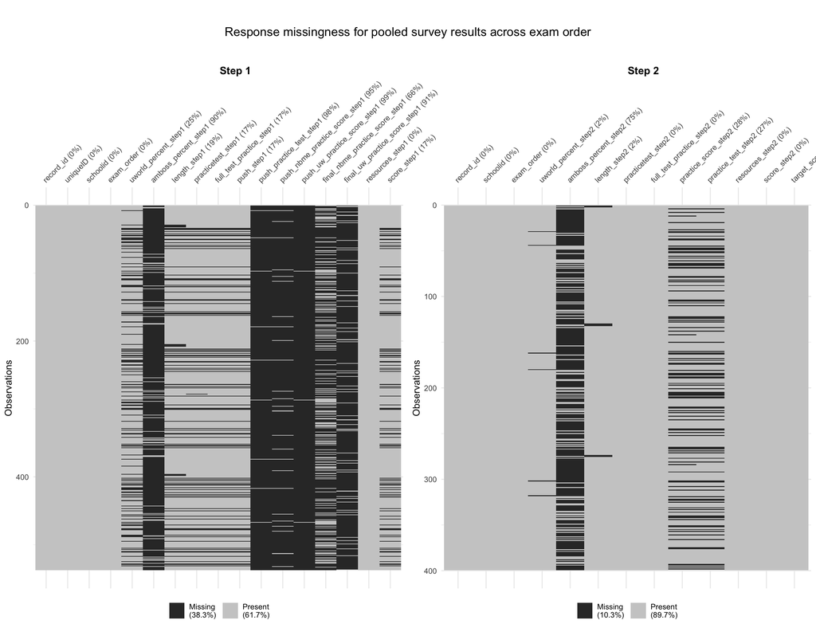

```r
######### visually profile missing responses
p1 <- visdat::vis_miss(step1_complete)
p2 <- visdat::vis_miss(step2_complete)

title_gg <- ggdraw() + draw_label("Response missingness for pooled survey results across exam order")
gridded <- plot_grid(p1, p2, label_size = 12, ncol = 2, align = "hv", label_x = 0.5,
          labels = c("Step 1","Step 2"))
plot_grid(title_gg, gridded, nrow = 2, rel_heights = c(0.1, 0.9))
```

# 2 Analysis

Note, we plan to use the robust/sandwich variance estimator for regression models. One inclusion criteria is that the outcome variable (“Y”) must be available for a subject to be included in the analysis question (ie. if they did not report a step 2 score, we won’t perform relevant step 2 analysis on them).

**Q1 Does order have an impact on Step 2 scores?**

We cannot analyze Step 1 since all survey responses reported passing For Step 2 scores, I will perform a linear regression with:

- Y = Step 2 score
- X = factor ( 1 = “step 1 first”, 2 = “step 2 first”, 3 = “only step 1”, 4 = “only step 2”)
- Z = school (need to adjust for this)

**Note**

still need to use robust se

```r
step2_complete[ ,"order_factor"]  <- factor(step2_complete$exam_order, levels = c(1,2, 3, 4), labels = c("step 1 first", "step 2 first", "only step 1", "only step 2"))
step2_complete[ ,"school_factor"]   <- factor(step2_complete$schoolid, labels = c("HMS", "UVA", "VUMS"))

table(step2_complete$exam_order)
```

```
  1   2   4
214 181   4
```

```r
exam_order_mod <- lm(formula = score_step2 ~ order_factor + school_factor, data = step2_complete)
sandwich(exam_order_mod) #this gives the sandwich variance
```

```
                         (Intercept) order_factorstep 2 first
(Intercept)                1.6640853             -0.516204082
order_factorstep 2 first  -0.5162041              2.373041881
order_factoronly step 2   -0.8343933              0.515236779
school_factorUVA          -1.6405082             -0.105407382
school_factorVUMS         -1.6593841              0.001934606
                         order_factoronly step 2 school_factorUVA
(Intercept)                          -0.83439325       -1.6405082
order_factorstep 2 first              0.51523678       -0.1054074
order_factoronly step 2               5.94333749        0.8138448
school_factorUVA                      0.81384481        3.0988138
school_factorVUMS                    -0.05159291        1.6533268
                         school_factorVUMS
(Intercept)                   -1.659384076
order_factorstep 2 first       0.001934606
order_factoronly step 2       -0.051592909
school_factorUVA               1.653326776
school_factorVUMS              3.421953971
```

```r
summary(exam_order_mod) #model summary for reporting
```

```
Call:
lm(formula = score_step2 ~ order_factor + school_factor, data = step2_complete)

Residuals:
     Min       1Q   Median       3Q      Max
-112.816   -5.523    3.184    8.377   21.759

Coefficients:
                         Estimate Std. Error t value Pr(>|t|)
(Intercept)              261.1405     1.4589 178.992   <2e-16 ***
order_factorstep 2 first  -1.8994     1.4832  -1.281    0.201
order_factoronly step 2   -6.9279     7.4321  -0.932    0.352
school_factorUVA           0.3822     1.7843   0.214    0.831
school_factorVUMS          0.5748     1.8396   0.312    0.755
---
Signif. codes:  0 '***' 0.001 '**' 0.01 '*' 0.05 '.' 0.1 ' ' 1

Residual standard error: 14.69 on 394 degrees of freedom
Multiple R-squared:  0.00609,   Adjusted R-squared:  -0.004
F-statistic: 0.6035 on 4 and 394 DF,  p-value: 0.6603
```

Based on the model output (p values), there doesn’t appear to be any signifigant associations between exam order and the score for Step 2. Since the $R^2$ value is essentially 0, I conclude that there was no effect of exam order on step 2 scores.

**Q2 What factors affect Step 2 score?**

Again, we cannot analyze Step 1 scores since all respondents reported passing.

Based on our SAP, if there are any covariates with more than 30% of responses missing, we will drop that variable or populate it with 0, depending on context. For example, the percent of Amboss questions completed will be filled with 0 for people who didn’t answer since it seems safe to assume they didn’t complete any of the Amboss questions. If less than 30% are missing, I may consider performing bootstrap sampling of known values to replace missing values.

After accounting for missingness, I will assess for co-linearity of the predictors (ie. correlation) using VIF. If there is high co-linearity, we will use LASSO to perform variable selection. If there is no evidence of concerning levels of colinearity, I will proceed with linear regression.

```r
######## profile missingness in the step 2 data and address
percents_missing <- round(colSums(is.na(step2_complete))/nrow(step2_complete), 3)*100
kable(percents_missing, caption = "Percent missing observations for pooled Step 2 survey")
```

Percent missing observations for pooled Step 2 survey

|  | x |
| --- | --- |
| record_id | 0.0 |
| schoolid | 0.0 |
| exam_order | 0.0 |
| uworld_percent_step2 | 1.5 |
| amboss_percent_step2 | 75.2 |
| length_step2 | 1.8 |
| practicetest_step2 | 0.0 |
| full_test_practice_step2 | 0.0 |
| practice_score_step2 | 27.8 |
| practice_test_step2 | 27.1 |
| resources_step2 | 0.0 |
| score_step2 | 0.0 |
| target_score_step2 | 0.0 |
| order_factor | 0.0 |
| school_factor | 0.0 |

```r
#inspecting percent missing, it seems like most responses are now complete except Amboss. Based on our study plan, I will populate those without a response for Amboss with 0's
step2_complete$amboss_percent_step2 <- ifelse(is.na(step2_complete$amboss_percent_step2) == TRUE, 0, step2_complete$amboss_percent_step2)
class(step2_complete$practicetest_step2) <- "integer"
step2_complete[,"on_target"] <-  factor(step2_complete$target_score_step2, levels = c(1,2,3), labels = c("at target", "above target", "below target"))


# after disucssing with the group, we decided the pairs plots were not helpful to display.
# ######## Making pairs plots to assess co linearity
# #this function is so I can customize the panels in the correlation pairs plots.
# tf = function(x,y) {
#   ct <- cor.test(x, y)
#   sprintf("Corr: %0.2f, p: %0.3f\n95%% CI: (%0.2f - %0.2f) \n n pairs = %.0f",
#           ct$estimate, ct$p.value, ct$conf.int[1], ct$conf.int[2], sum(!is.na(x), !is.na(y))/2)
# }  #https://stackoverflow.com/questions/75068871/add-p-value-and-or-95-ci-in-the-text-of-a-correlation-matrix-pairs-plot
#
# ggpairs(step2_complete[,c("uworld_percent_step2", "amboss_percent_step2", "length_step2", "practicetest_step2",  "full_test_practice_step2", "practice_score_step2", "practice_test_step2", "on_target", "score_step2")], title="Step 2 scores and predictors pairs plots", upper=list(continuous=wrap("statistic",text_fn=tf,title=NULL, sep=NULL)), progress = FALSE)
```

Multiple linear regression with:

- Y = Step 2 score
- X1 = % UWorld
- X2 = % Amboss
- X3 = length study
- X4 = # of practice tests
- X5 = full test day (yes/no code as binary)
- X6 = final practice score (however, is there some conversion between U World and Amboss - Jeffrey is looking into this)
- Z = School (need to adjust for this)

I decided to exclude the number of practice tests (covariate X4) since unique the responses were so few: ————> ACTUALLY NEED TO INCLUDE AND DO DATA CLEANING ON X4!!!

```r
unique(step2_complete$practicetest_step2)
```

```
 [1]  6  1  4  5  3 NA  2  7  8 11
```

```r
table(step2_complete$practicetest_step2)
```

```
 1  2  3  4  5  6  7  8 11
 9 21 42 90 92 90 25  9  3
```

Below I report the model results, sandqich variance, and VIF for step 2 scores model.

```r
step2_complete$simulate_full_practice <- ifelse(step2_complete$full_test_practice_step2 <= 2, 0, 1)
step2_complete$simulate_full_practice <- factor(step2_complete$simulate_full_practice, levels = c(0, 1), labels = c("Yes", "No"))
step2_complete$length_step2 <- factor(step2_complete$length_step2 , levels = c(1:6), labels = c("less than 1 week", "1-2 weeks", "3-4 weeks", "5-6 weeks", "7-8 weeks", "more than 8 weeks"))

mod_step2_scores <- lm(score_step2 ~ uworld_percent_step2 + amboss_percent_step2 + length_step2 + simulate_full_practice + practice_score_step2 + school_factor, data = step2_complete)
summary(mod_step2_scores)
```

```
Call:
lm(formula = score_step2 ~ uworld_percent_step2 + amboss_percent_step2 +
    length_step2 + simulate_full_practice + practice_score_step2 +
    school_factor, data = step2_complete)

Residuals:
     Min       1Q   Median       3Q      Max
-24.3826  -3.9447   0.1815   5.3167  19.6122

Coefficients:
                               Estimate Std. Error t value Pr(>|t|)
(Intercept)                    71.30898    8.61801   8.274 6.12e-15 ***
uworld_percent_step2            0.01549    0.02467   0.628 0.530735
amboss_percent_step2            0.02384    0.02403   0.992 0.322107
length_step25-6 weeks           1.03866    1.26117   0.824 0.410917
length_step27-8 weeks          -3.54309    1.48080  -2.393 0.017415 *
length_step2more than 8 weeks -10.74882    2.84111  -3.783 0.000191 ***
simulate_full_practiceNo       -0.06601    1.17310  -0.056 0.955170
practice_score_step2            0.73270    0.03287  22.289  < 2e-16 ***
school_factorUVA                0.63160    1.30363   0.484 0.628430
school_factorVUMS               0.56528    1.32384   0.427 0.669721
---
Signif. codes:  0 '***' 0.001 '**' 0.01 '*' 0.05 '.' 0.1 ' ' 1

Residual standard error: 8.841 on 268 degrees of freedom
  (121 observations deleted due to missingness)
Multiple R-squared:  0.7255,    Adjusted R-squared:  0.7163
F-statistic: 78.69 on 9 and 268 DF,  p-value: < 2.2e-16
```

```r
sandwich(mod_step2_scores)
```

```
                               (Intercept) uworld_percent_step2
(Intercept)                   205.61905313        -2.132629e-02
uworld_percent_step2           -0.02132629         4.085732e-04
amboss_percent_step2            0.06648763         8.162770e-05
length_step25-6 weeks          -1.45693379        -1.309239e-03
length_step27-8 weeks          -2.24294514         3.971173e-03
length_step2more than 8 weeks  -0.42023043         1.964338e-03
simulate_full_practiceNo        0.01271774         2.191968e-03
practice_score_step2           -0.78303086        -5.601645e-05
school_factorUVA               -0.89825159         1.393446e-03
school_factorVUMS              -0.82509286         1.714632e-03
                              amboss_percent_step2 length_step25-6 weeks
(Intercept)                           0.0664876250          -1.456933787
uworld_percent_step2                  0.0000816277          -0.001309239
amboss_percent_step2                  0.0003352648          -0.006043151
length_step25-6 weeks                -0.0060431514           1.165890049
length_step27-8 weeks                -0.0050542327           0.554811815
length_step2more than 8 weeks         0.0040657081           0.216828391
simulate_full_practiceNo              0.0028820653          -0.118354658
practice_score_step2                 -0.0002983228           0.004511585
school_factorUVA                      0.0011393946           0.030455332
school_factorVUMS                     0.0009071053           0.010855734
                              length_step27-8 weeks
(Intercept)                            -2.242945143
uworld_percent_step2                    0.003971173
amboss_percent_step2                   -0.005054233
length_step25-6 weeks                   0.554811815
length_step27-8 weeks                   1.927119464
length_step2more than 8 weeks           0.219219504
simulate_full_practiceNo               -0.170418164
practice_score_step2                    0.005960500
school_factorUVA                        0.088164940
school_factorVUMS                       0.037493650
                              length_step2more than 8 weeks
(Intercept)                                    -0.420230433
uworld_percent_step2                            0.001964338
amboss_percent_step2                            0.004065708
length_step25-6 weeks                           0.216828391
length_step27-8 weeks                           0.219219504
length_step2more than 8 weeks                  19.261294829
```

[output cut: 11 more lines]

```
simulate_full_practiceNo                   1.281020182        -3.987353e-03
practice_score_step2                      -0.003987353         3.052750e-03
school_factorUVA                          -0.035555784        -3.315934e-04
school_factorVUMS                         -0.014776419        -7.170283e-04
                              school_factorUVA school_factorVUMS
(Intercept)                      -0.8982515864     -0.8250928605
uworld_percent_step2              0.0013934463      0.0017146315
amboss_percent_step2              0.0011393946      0.0009071053
length_step25-6 weeks             0.0304553320      0.0108557341
length_step27-8 weeks             0.0881649402      0.0374936497
length_step2more than 8 weeks    -0.1510078290      0.1002857149
simulate_full_practiceNo         -0.0355557839     -0.0147764187
practice_score_step2             -0.0003315934     -0.0007170283
school_factorUVA                  1.6205254920      0.8591329661
school_factorVUMS                 0.8591329661      1.6905210439
```

```r
vif(mod_step2_scores)
```

```
         uworld_percent_step2          amboss_percent_step2
                     1.050611                      1.077134
        length_step25-6 weeks         length_step27-8 weeks
                     1.368574                      1.351480
length_step2more than 8 weeks      simulate_full_practiceNo
                     1.279782                      1.032096
         practice_score_step2              school_factorUVA
                     1.204445                      1.386014
            school_factorVUMS
                     1.380191
```

```r
# rms::robcov(mod_step2_scores) this is what I would use to get the robust se estimates but when I try to swtich the above model to ols from the rms package I have trouble getting it to run

# modelsummary::modelsummary(list("Step 2 scores" = rms::robcov(mod_step2_scores)),
#              output = 'kableExtra',
#              fmt = fmt_sprintf("%.4f"),
#              estimate = "{estimate} [{conf.low}, {conf.high}]",
#              statistic = "p: {p.value}")
```

**Warning**

I need help with getting the robust estimator working in my model

I looked into the difference between practice_test_step2 (the final practice test I took before my exam was… 8 options) and practicetest_step2 (text response of how many practice tests did you take before step 2). I decided not to include either in the model.

**Note**

I did not perform lasso. would be happy to implement it if we can look it up.

Last time I made the pairs, plot I noticed there is a relationship between

- “practice test” and “length”
- “practice score” and “length”
- “score” and “length” (this makes a lot of sense)
- practice score and target score (also makes sense)
- score and target

**Q3 What is associated (in this data) with pushing back a Step 1 exam date?**

Here, I will perform logistic regression with

Y = yes or no (1 = yes, 2 = no for “push_step1”)

- push remember step1 (1 = I only remember the form name, 2 = I only remember the score, 3 = I remember the form name and the score, 4 = I don’t remember either) - we decided not to include this variable (can change later if desired)
- push score only step 1 (1 = NBME, 2 = Uworld)
- push practice test step 1 ( 1 - 8 listing various exams)
- push nbme practice score (from 0 to 100%)
- push uw practice score (from 180 to 300)

Listing variables by name and if I have included them:

- “push_step1_1” yes
- “push_remember_step1_1” not included b/c a precursor question
- “push_score_only_step1_1” not currently included but could be
- “push_practice_test_step1_1” yes
- “push_nbme_practice_score_step1_1” yes
- “push_uw_practice_score_step1_1” yes

```r
step1_complete$push_step1 <- ifelse(step1_complete$push_step1 == 2 | is.na(step1_complete$push_step1) ==TRUE, 2, 1) #recording the NA's to be "No" (they did not push back step 1)
step1_complete$push_step1_label <- factor(step1_complete$push_step1, levels = c(1, 2), labels = c("Yes", "No")) #making a nice descriptive label

did_push_df <- step1_complete %>% filter(push_step1_label == "Yes")
dat %>% filter(!is.na(push_remember_step1_1))
```

[output not shown]

[output cut: 1245 more lines]

```r
step1_complete$push_practice_test_step1 <- factor(step1_complete$push_practice_test_step1, levels = c(1:8), labels = c("NBME 25", "NBME 26", "NBME 27", "NBME 28", "NBME 29", "NBME 30", "UWorld 1", "UWorld 2"))

units(step1_complete$push_uw_practice_score_step1) <- "score units"
units(step1_complete$push_nbme_practice_score_step1) <- "percent"
label(step1_complete$push_practice_test_step1) <- "exam that triggered pushing back"
label(step1_complete$push_nbme_practice_score_step1) <- "NBME P(passing) that triggered pushing back"
label(step1_complete$push_uw_practice_score_step1) <- "3 digit UWorld score that triggered pushing back"
caption <- "Description of indiviuals that pushed back Step 1"
table1(~ push_practice_test_step1 + push_uw_practice_score_step1 + push_nbme_practice_score_step1 |push_step1_label, data=step1_complete, topclass="Rtable1-zebra")
```

|  | Yes (N=62) | No (N=475) | Overall (N=537) |
| --- | --- | --- | --- |
| exam that triggered pushing back |  |  |  |
| NBME 25 | 0 (0%) | 0 (0%) | 0 (0%) |
| NBME 26 | 0 (0%) | 0 (0%) | 0 (0%) |
| NBME 27 | 3 (4.8%) | 0 (0%) | 3 (0.6%) |
| NBME 28 | 3 (4.8%) | 0 (0%) | 3 (0.6%) |
| NBME 29 | 0 (0%) | 0 (0%) | 0 (0%) |
| NBME 30 | 0 (0%) | 0 (0%) | 0 (0%) |
| UWorld 1 | 0 (0%) | 0 (0%) | 0 (0%) |
| UWorld 2 | 3 (4.8%) | 0 (0%) | 3 (0.6%) |
| Missing | 53 (85.5%) | 475 (100%) | 528 (98.3%) |
| 3 digit UWorld score that triggered pushing back (score units) |  |  |  |
| Mean (SD) | 180 (0) | NA (NA) | 180 (0) |
| Median [Min, Max] | 180 [180, 180] | NA [NA, NA] | 180 [180, 180] |
| Missing | 59 (95.2%) | 475 (100%) | 534 (99.4%) |
| NBME P(passing) that triggered pushing back (percent) |  |  |  |
| Mean (SD) | 67.3 (17.7) | NA (NA) | 67.3 (17.7) |
| Median [Min, Max] | 70.0 [30.0, 87.0] | NA [NA, NA] | 70.0 [30.0, 87.0] |
| Missing | 37 (59.7%) | 475 (100%) | 512 (95.3%) |

**Descriptive Statistics (not done yet)**

Descriptive statistics will be reported by school and total.

- histogram of Step 2 scores
- what resources are most widely used barplot
- how long did students study barplot
- number of practice tests histogram (among the people who answered the question)
- summarize comments (other_resources, other_step, changes_step)

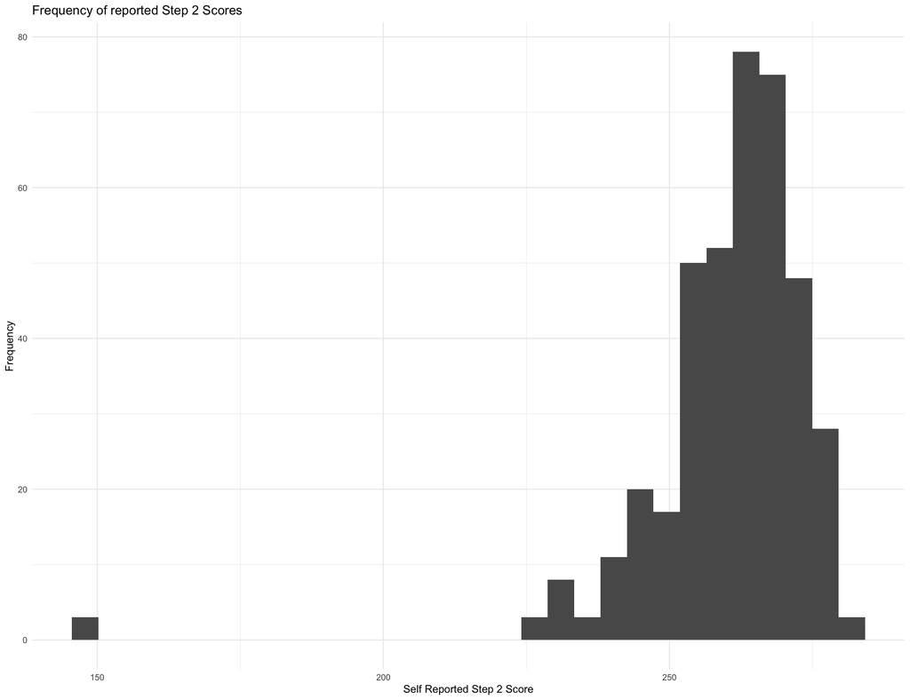

```r
## do a plot for all schools (in total) as well as Vanderbilt in particular
## use a unified color scheme

ggplot(aes(x = score_step2), data= step2_complete) + geom_histogram() + theme_minimal() + xlab("Self Reported Step 2 Score") + ylab("Frequency") + labs(title = "Frequency of reported Step 2 Scores")
```

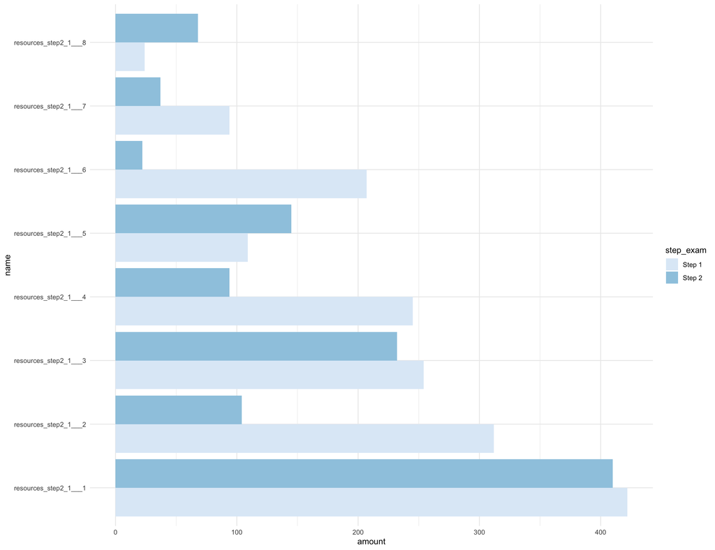

```r
#more data cleaning first first step 2 for the resouces they selected that they used
resources_step2 <- colSums(took_step2general[20:35])
uworld <- resources_step2[1] + resources_step2[9]
first_aid <- resources_step2[2] + resources_step2[10]
anki <- resources_step2[3] + resources_step2[11]
sketchy <- resources_step2[4] +resources_step2[12]
amboss <- resources_step2[5] + resources_step2[13]
pathoma <- resources_step2[6] + resources_step2[14]
boards_and_beyond <- resources_step2[7] + resources_step2[15]
other <- resources_step2[8] + resources_step2[16]
totals <- c(uworld, first_aid, anki, sketchy, amboss, pathoma, boards_and_beyond, other)

#same idea for step 1
resources_step1 <- colSums(took_step1general[26:41])
uworld1 <- resources_step1[1] + resources_step1[9]
first_aid1 <- resources_step1[2] + resources_step1[10]
anki1 <- resources_step1[3] + resources_step1[11]
sketchy1 <- resources_step1[4] +resources_step1[12]
amboss1 <- resources_step1[5] + resources_step1[13]
pathoma1 <- resources_step1[6] + resources_step1[14]
boards_and_beyond1 <- resources_step1[7] + resources_step1[15]
other1 <- resources_step1[8] + resources_step1[16]
totals1 <- c(uworld1, first_aid1, anki1, sketchy1, amboss1, pathoma1, boards_and_beyond1, other1)

rdf <- data.frame(amount = c(totals, totals1), name = rep(names(totals), 2), step_exam = c(rep("Step 2", 8), rep("Step 1", 8) ))

# http://www.sthda.com/english/wiki/ggplot2-barplots-quick-start-guide-r-software-and-data-visualization used this as a guide

#what resources are most widely used? I want to sort this barplot in order of frequency but for some reason this wasn't working for me with reorder()
ggplot(data=rdf, aes(x=name, y=amount, fill = step_exam)) +
  geom_bar(stat="identity", position=position_dodge())+
  theme_minimal() + coord_flip() + scale_fill_brewer(palette="Blues")
```

```r
## how long did the students study barplot


## number of practice tests histogram (among the people who answered the question)


## summarize comments (other_resources, other_step, changes_step)
#dat$study_amount_step1_1
```

# 3 Appendix/notes

All the analyses are performed using the following:

- R version 4.2.2 (2022-06-24); R Core Team (2022). R: A language and environment for statistical computing. R Foundation for Statistical Computing, Vienna, Austria. URL https://www.R-project.org/.
- Harrell Jr FE (2022). rms: Regression Modeling Strategies. R package version 6.3-0, https://CRAN.R-project.org/package=rms.

The table below lists packages used in this document.

```r
subset(data.frame(sessioninfo::package_info()), attached==TRUE, c(package, loadedversion))
```

```
                  package loadedversion
cowplot           cowplot         1.1.1
dplyr               dplyr         1.1.3
forcats           forcats         1.0.0
GGally             GGally         2.1.2
ggplot2           ggplot2         3.4.4
gridExtra       gridExtra           2.3
Hmisc               Hmisc         5.1-1
knitr               knitr          1.44
lubridate       lubridate         1.9.3
modelsummary modelsummary         1.4.3
plotly             plotly        4.10.2
purrr               purrr         1.0.2
readr               readr         2.1.4
rms                   rms         6.7-1
sandwich         sandwich         3.0-2
scales             scales         1.2.1
stringr           stringr         1.5.0
table1             table1         1.4.3
tibble             tibble         3.2.1
tidyr               tidyr         1.3.0
tidyverse       tidyverse         2.0.0
viridis           viridis         0.6.4
viridisLite   viridisLite         0.4.2
visdat             visdat         0.6.0
```